# Unveiling the signaling network of FLT3-ITD AML improves drug sensitivity prediction

FLT3-ITD patients: Functional impact annotation of mutations

Veronica Venafra

2023-10-25

## OncoKB Annotation

The maf files containing the mutations of each patient were annotated with OncoKB™ annotator (Chakravarty et al., 2016) to obtain the mutation effect on protein function and oncogenicity. In the following code, we filtered out variants with MUTATION_EFFECT equal to ‘Unknown’, ‘Inconclusive’, ‘Likely Neutral’, and ‘Switch-of-function’.

The code below creates the *sheet 2* of **Table S5**.

```r
onco_p <- read_tsv('./input/oncokb-annotator/all_patients_onco.maf')

onco_p_new_col <- onco_p %>%
  dplyr::select(Tumor_Sample_Barcode,
         Hugo_Symbol, Entrez_Gene_Id,
         Chromosome, Start_Position, End_Position, Strand,
         HGVSc, HGVSp, HGVSp_Short,
         MUTATION_EFFECT, ONCOGENIC)

# filter all mutations except the ones not known
onco_p_new_col_k <- onco_p_new_col  %>% filter(MUTATION_EFFECT != 'Unknown' &
                                               MUTATION_EFFECT != 'Inconclusive' &
                                               MUTATION_EFFECT != 'Likely Neutral' &
                                               MUTATION_EFFECT != 'Switch-of-function')

write_tsv(onco_p_new_col, './result/oncokb/oncokb_annotated_filtered.maf')
```

## Binarization of mutations impacting protein function

The binarization process consists in converting: - Gain of Function mutation as 2. - Loss of Function mutation as 1. - No mutation as 0.

The result of this code is **Table S5**, sheet 3.

```r
onco_p_new_col <- read_tsv('./result/oncokb/oncokb_annotated_filtered.maf')
onco_p_new_col$MUT_CODE[grepl('Loss', onco_p_new_col$MUTATION_EFFECT)] <- 0
onco_p_new_col$MUT_CODE[grepl('Gain', onco_p_new_col$MUTATION_EFFECT)] <- 1

mutation_matrix <- onco_p_new_col %>% dplyr::select(Hugo_Symbol, Tumor_Sample_Barcode, MUT_CODE) %>% distinct()

clust_tib <- pivot_wider(mutation_matrix, names_from = Hugo_Symbol, values_from = MUT_CODE)

clust_tib[,'FLT3'] <- 2 # everyone has FLT3-ITD
clust_tib[clust_tib==1] <- 2 #gain of function
clust_tib[clust_tib==0] <- 1 #loss of function
clust_tib[is.na(clust_tib)] <- 0

write_tsv(clust_tib, './result/oncokb/mutational_profile_whole.tsv')
```

## Visualization

### Clustering of mutations

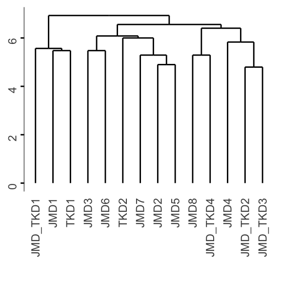

```r
onco_p_new_col <- read_tsv('./result/oncokb/oncokb_annotated_filtered.maf', show_col_types = FALSE)
onco_p_new_col$MUT_CODE[grepl('Loss', onco_p_new_col$MUTATION_EFFECT)] <- 0
onco_p_new_col$MUT_CODE[grepl('Gain', onco_p_new_col$MUTATION_EFFECT)] <- 1

mutation_matrix <- onco_p_new_col %>%
  dplyr::select(Hugo_Symbol, Tumor_Sample_Barcode = type, MUT_CODE) %>%
  distinct()

clust_tib <- pivot_wider(mutation_matrix, names_from = Hugo_Symbol, values_from = MUT_CODE)

clust_tib <- clust_tib %>%
  column_to_rownames('Tumor_Sample_Barcode')

clust_tib <- clust_tib %>%
  mutate_all(as.numeric)

clust_tib[,'FLT3'] <- 2 # everyone has FLT3-ITD
clust_tib[clust_tib==1] <- 2 #gain of function
clust_tib[clust_tib==0] <- 1 #loss of function
clust_tib[is.na(clust_tib)] <- 0

whole_d = dist(clust_tib, method = 'euclidean')
whole_hc = hclust(whole_d, method = 'complete')

hc_plot <- ggdendrogram(whole_hc, theme_dendro = TRUE) +
  theme(axis.line.y = element_line(colour = 'darkgrey'),
        axis.ticks.y = element_line())

hc_plot
```

**Figure 5C**. Clustering according to the mutational profile of each patient.

### Heatmap of mutations

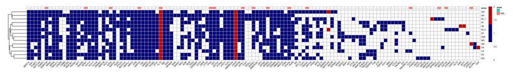

```r
onco_p_new_col <- read_tsv('./result/oncokb/oncokb_annotated_filtered.maf', show_col_types = FALSE)
onco_p_new_col$MUT_CODE[grepl('Loss', onco_p_new_col$MUTATION_EFFECT)] <- 0
onco_p_new_col$MUT_CODE[grepl('Gain', onco_p_new_col$MUTATION_EFFECT)] <- 1

mutation_matrix <- onco_p_new_col %>%
  dplyr::select(Hugo_Symbol, Tumor_Sample_Barcode, MUT_CODE) %>%
  distinct()

clust_tib <- pivot_wider(mutation_matrix, names_from = Hugo_Symbol, values_from = MUT_CODE)

clust_tib <- clust_tib %>%
  column_to_rownames('Tumor_Sample_Barcode')

clust_tib <- clust_tib %>%
  mutate_all(as.numeric)

clust_tib[,'FLT3'] <- 2 # everyone has FLT3-ITD
clust_tib[clust_tib==1] <- 2 #gain of function
clust_tib[clust_tib==0] <- 1 #loss of function
clust_tib[is.na(clust_tib)] <- 0

myColor <- colorRampPalette(c("white", 'darkblue',"red3"))(3)

# annotate columns for AML driver genes
aml_genes <- c('FLT3','KRAS','NRAS','KIT','PTPN11','NF1','DNMT3A','IDH1',
               'IDH2','TET2','ASXL1','EZH2','KMT2A','NPM1','CEBPA',
               'RUNX1','GATA2','TP53','SRSF2','U2AF1','SF3B1','ZRSR2','RAD21',
               'STAG1','STAG2','SMC1A','SMC3')

col_anno <- tibble(genes = names(clust_tib), anno = c(rep('', length(names(clust_tib)))))
col_anno$anno[col_anno$genes %in% aml_genes] <- 'AML'
col_anno <- col_anno %>% column_to_rownames('genes')


p <- pheatmap(clust_tib,
              color = myColor,
              annotation_col = col_anno,
              #display_numbers = TRUE,
              cellwidth = 10,
              cellheight = 10,
              cluster_rows = TRUE,
              cluster_cols = FALSE,
              border_color = 'grey',
              #breaks = breaks,
              #legend_breaks = -100,
              fontsize = 6,
              width = 5,
              heigth = 30,
              angle_col = c('45'))
```

**Figure S6A** Mutational landscape of FLT3-ITD patients.

### Barplot of average mutations burden

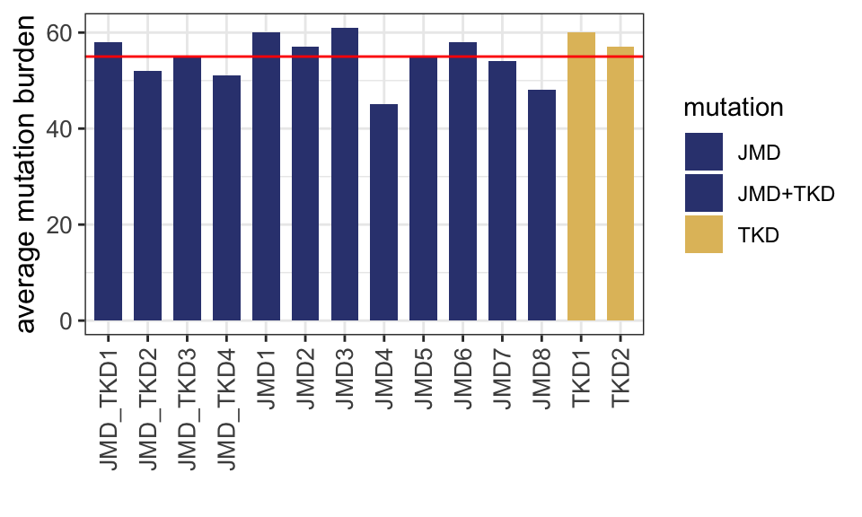

```r
# Read mutation data and the mapping of ITD classification to patient ID
mutations_df <- read_tsv('./result/oncokb/mutational_profile_whole.tsv')

mapping <- read_tsv('./result/getitd/mapping_getitd_patientID.tsv')

mutations <- inner_join(mutations_df,
                        mapping %>% dplyr::select(sample, type),
                        by = c('Tumor_Sample_Barcode' = 'sample'))
mutations$Tumor_Sample_Barcode <- NULL
mutations <- mutations %>% rename('type' = 'sample')

# Average mutation burden
mutations_t <- t(mutations)

mutations <- mutations %>% column_to_rownames('sample')
round(rowSums(mutations,  na.rm=TRUE)/nrow(mutations_t)*100,0) -> v

count_mut_df <- tibble(patients = names(v), mean = v)

count_mut_df <- inner_join(count_mut_df,
                           mapping %>%
                             dplyr::select(type, mutation),
                           by = c('patients' = 'type'))

plot <- ggplot(count_mut_df, aes(x = patients, y = mean, fill = mutation)) +
  geom_bar(stat = 'identity', width = 0.7) +
  scale_fill_manual(values = c('#35427F', '#35427F','#E1BE6A'))+
  geom_hline(yintercept = 55, col ='red')+
  xlab('')+
  ylab('average mutation burden')+
  theme_bw()+
  theme(axis.text.x = element_text(angle = 90, vjust = 0.5, hjust=1, size = 10),
        axis.text.y = element_text(size = 10),
        axis.title = element_text(size = 12))

plot
```

**Figure S6B** Bar plot reporting the number of mutations for each patient. The red line represents the average number of mutations (55).

### Mutational profile of model genes

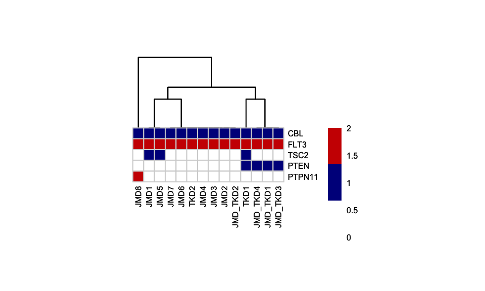

```r
onco_p_new_col <- read_tsv('./result/oncokb/oncokb_annotated_filtered.maf', show_col_types = FALSE)
onco_p_new_col$MUT_CODE[grepl('Loss', onco_p_new_col$MUTATION_EFFECT)] <- 0
onco_p_new_col$MUT_CODE[grepl('Gain', onco_p_new_col$MUTATION_EFFECT)] <- 1

mutation_matrix <- onco_p_new_col %>%
  dplyr::select(Hugo_Symbol, Tumor_Sample_Barcode = type, MUT_CODE) %>%
  distinct()

clust_tib <- pivot_wider(mutation_matrix, names_from = Hugo_Symbol, values_from = MUT_CODE)

clust_tib <- clust_tib %>%
  column_to_rownames('Tumor_Sample_Barcode')

clust_tib <- clust_tib %>%
  mutate_all(as.numeric)

clust_tib[,'FLT3'] <- 2 # everyone has FLT3-ITD
clust_tib[clust_tib==1] <- 2 #gain of function
clust_tib[clust_tib==0] <- 1 #loss of function
clust_tib[is.na(clust_tib)] <- 0



# create files
model_nodes <- c('AKT','CBL','CREB1','ERK1/2','FLT3','GRB2','GSK3A',
                 'GSK3B','IGF1R','INSR','IRS1','JNK','KIT','KRAS',
                 'MAPK14','MEK1/2','MTOR','PDPK1','PI3K','PTEN','PTPN1',
                 'PTPN11','RPS6','RPS6KA1','RPS6KB1','SHC1','STAT3','STAT5A','TNF','TSC2')

model_clust_tb <- clust_tib[, colnames(clust_tib) %in% model_nodes]

write_tsv(model_clust_tb %>%
            rownames_to_column('Patient'),
          './result/oncokb/mutational_profile_model_code.tsv')

myColor <- colorRampPalette(c("white", 'darkblue',"red3"))(3)

p <- pheatmap(t(model_clust_tb),
              color = myColor,
              #display_numbers = TRUE,
              cellwidth = 8,
              cellheight = 8,
              cluster_rows = FALSE,
              cluster_cols = TRUE,
              border_color = 'lightgrey',
              #breaks = breaks,
              #legend_breaks = -100,
              fontsize = 6,
              width = 5,
              heigth = 30,
              angle_col = c('90'))

p
```

**Figure S6D** Heatmap reporting the mutational profile of patients restricted to genes present in the cell-derived Boolean model. White, blue and red squares represent wild type genes, ‘Loss Of Function’ (LOF) and ‘Gain Of Function’ (GOF) mutations, respectively.